# Momentary degree and concurrency

Data on momentary degree among HIV-negative/unknown status men are from the WHPP survey, and data on momentary degree among HIV-positive men are from the national ART-Net survey reweighted to the age and racial/ethnic profile of Washington males. We combine the re-weighted datasets to get estimates of degree.

**Balancing issues**: Several model inputs are calculated from data on the distribution of active main and persistent partnerships and instantaneous partnerships in the past year. These include patterns of race and age mixing, cross-network degree distributions, and rates of instantaneous partnerships. Adjustments made to balance the racial/ethnic mixing matrices modify group-specific degrees, so additional adjustments are required to the cross-network degree distributions and rates of instantaneous partnerships to ensure that the implied number of partnerships for each group and the total network are consistent.

Because of uncertainty about the causes of imbalances in the mixing matrices and the implications of adjusting for them, we calculate these inputs in two ways (see section @ref(racemixing)):

1. We will use the observed egocentric data on momentary degree and the unbalanced racial/ethnic mixing matrices. To account for differential missingness on questions relating to current main and casual partnership counts in the WHPP sample (there are no missing data among HIV-positive men in the ART-Net sample), we impute values for respondents with missing data as the mean value among men who match on race/ethnicity, region, and age (40-49 vs other ages). This assumes that there is non-differential missingness, but it ensures that degree distributions by subgroup are consistent and imply the same total number of partnerships (see [issue 39](https://github.com/statnet/WHAMP/issues/39)).
2. We will balance the race/ethnicity mixing matrices as described in section @ref(racemixing) and obtain the racial/ethnic group-specific mean degrees from these balanced matrices. We will then adjust the cross-network momentary degree distribution to bump the margins up or down to match these mean degrees by increasing/decreasing each cell proportionately. To adjust this matrix to match persistent degree, we will make adjustments to the “0 persistent” and “1 persistent” columns and leave the “2 persistent” column unchanged.

We will fit the model using target statistics calculated both ways and evaluate which results in networks with the features we expect, and/or how much of a difference on our outcomes the two parameter sets make (see [issue #44](https://github.com/statnet/WHAMP/issues/44)).

## Momentary degree distribution

### Overall

Tables @ref(tab:degmatrix) and @ref(tab:degmatrix_adj), below, present the overall momentary degree distribution based on the data reported by egos and based on the weighted average of the race-specific matrices adjusted to correspond to the balanced mixing matrices, respectively. Note that the margins are the same for these.

Observed main and persistent degree distribution

|  | 0 pers | 1 pers | 2+ pers | Total |
| --- | --- | --- | --- | --- |
| No main | 0.3947 | 0.0792 | 0.0780 | 0.5519 |
| Main | 0.3402 | 0.0474 | 0.0605 | 0.4481 |
| Total | 0.7349 | 0.1266 | 0.1384 | 1.0000 |

Adjusted main and persistent degree distribution

|  | 0 pers | 1 pers | 2+ pers | Total |
| --- | --- | --- | --- | --- |
| No main | 0.3964 | 0.0774 | 0.0781 | 0.5519 |
| Main | 0.3385 | 0.0493 | 0.0603 | 0.4481 |
| Total | 0.7349 | 0.1266 | 0.1384 | 1.0000 |

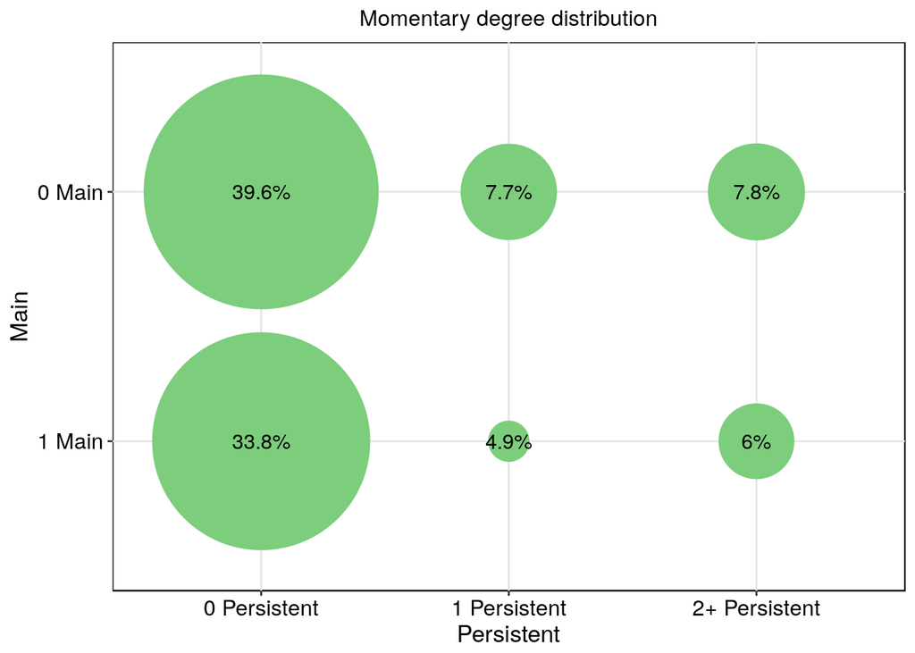

### By race/ethnicity To assign main and persistent degree as a nodal attribute according to race/ethnicity, region, and age, we will also need the degree distributions by these characteristics.

Tables @ref(tab:degmatrix_hisp)-@ref(tab:degmatrix_other_adj), below, present the momentary degree distributions by racial/ethnic group based on the data reported by egos (i.e. without adjusting for inconsistencies with the mean degrees implied by balanced mixing matrices) and after adjusting to the mean degrees implied by the balanced mixing matrices.

Main and persistent degree distribution: Hispanic men

|  | 0 pers | 1 pers | 2+ pers | Total |
| --- | --- | --- | --- | --- |
| No main | 0.3576 | 0.0820 | 0.0650 | 0.5047 |
| Main | 0.3954 | 0.0518 | 0.0481 | 0.4953 |
| Total | 0.7530 | 0.1338 | 0.1131 | 1.0000 |

Main and persistent degree distribution: Hispanic men, adjusted to align with balanced mixing matrices

|  | 0 pers | 1 pers | 2+ pers | Total |
| --- | --- | --- | --- | --- |
| No main | 0.2294 | 0.1668 | 0.0595 | 0.4558 |
| Main | 0.3232 | 0.1675 | 0.0536 | 0.5442 |
| Total | 0.5526 | 0.3343 | 0.1131 | 1.0000 |

Main and persistent degree distribution: Black men

|  | 0 pers | 1 pers | 2+ pers | Total |
| --- | --- | --- | --- | --- |
| No main | 0.4963 | 0.0590 | 0.1026 | 0.6579 |
| Main | 0.2556 | 0.0241 | 0.0624 | 0.3421 |
| Total | 0.7519 | 0.0831 | 0.1650 | 1.0000 |

Main and persistent degree distribution: Black men, adjusted to align with balanced mixing matrices

|  | 0 pers | 1 pers | 2+ pers | Total |
| --- | --- | --- | --- | --- |
| No main | 0.4525 | 0.0948 | 0.101 | 0.6483 |
| Main | 0.2429 | 0.0448 | 0.064 | 0.3517 |
| Total | 0.6954 | 0.1396 | 0.165 | 1.0000 |

Main and persistent degree distribution: Other race/ethnicity men

|  | 0 pers | 1 pers | 2+ pers | Total |
| --- | --- | --- | --- | --- |
| No main | 0.3921 | 0.0804 | 0.0779 | 0.5503 |
| Main | 0.3393 | 0.0485 | 0.0619 | 0.4497 |
| Total | 0.7313 | 0.1289 | 0.1398 | 1.0000 |

Main and persistent degree distribution: Other race/ethnicity men, adjusted to align with balanced mixing matrices

|  | 0 pers | 1 pers | 2+ pers | Total |
| --- | --- | --- | --- | --- |
| No main | 0.4140 | 0.0645 | 0.0789 | 0.5574 |
| Main | 0.3475 | 0.0342 | 0.0609 | 0.4426 |
| Total | 0.7615 | 0.0987 | 0.1398 | 1.0000 |

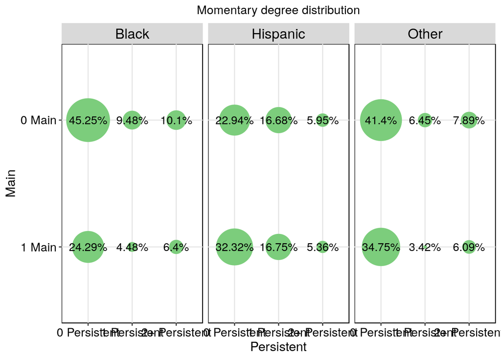

### By region Since the data on HIV-positive men are from a national sample (ART-Net), we don’t have data on the regional distribution within Washington of momentary degree among HIV-positives. As such, we will assume that the relative distribution of main and pesistent degree among HIV-negative men in the WHPP sample is representative of the degree distribution in the full sample. We will estimate the proportion of main and persistent degree among HIV-negative men in the re-weighted sample that are in each region, and use this proportion to calculate the target statistics in the full network.

Because balancing the racial/ethnic mixing matrices resulted in adjustments to the mean degree for each racial/ethnic group, there may be inconsistencies in the model with the implied number of partnerships by region from the observed data. To evaluate this, we define region-specific degree parameters using both the observed data and estimates of degree defined as weighted averages of the racial/ethnic specific degree distributions.

First we will look at the full observed momentary degree distributions by region among HIV-negative men, and the adjusted degree distributions calculated as weighted averages of the racial/ethnic group-specific degree distributions.

Main and persistent degree distribution: King County - observed

|  | 0 pers | 1 pers | 2+ pers | Total |
| --- | --- | --- | --- | --- |
| No main | 0.3582 | 0.0824 | 0.0739 | 0.5145 |
| Main | 0.3817 | 0.0463 | 0.0574 | 0.4855 |
| Total | 0.7399 | 0.1287 | 0.1314 | 1.0000 |

Main and persistent degree distribution: King County - adjusted

|  | 0 pers | 1 pers | 2+ pers | Total |
| --- | --- | --- | --- | --- |
| No main | 0.3991 | 0.0765 | 0.0786 | 0.5543 |
| Main | 0.3374 | 0.0478 | 0.0605 | 0.4457 |
| Total | 0.7365 | 0.1244 | 0.1391 | 1.0000 |

Main and persistent degree distribution: Other western WA - observed

|  | 0 pers | 1 pers | 2+ pers | Total |
| --- | --- | --- | --- | --- |
| No main | 0.4903 | 0.0691 | 0.0511 | 0.6105 |
| Main | 0.2888 | 0.0505 | 0.0503 | 0.3895 |
| Total | 0.7790 | 0.1195 | 0.1015 | 1.0000 |

Main and persistent degree distribution: Other western WA - adjusted

|  | 0 pers | 1 pers | 2+ pers | Total |
| --- | --- | --- | --- | --- |
| No main | 0.3986 | 0.0756 | 0.0782 | 0.5524 |
| Main | 0.3399 | 0.0473 | 0.0604 | 0.4476 |
| Total | 0.7385 | 0.1229 | 0.1386 | 1.0000 |

Main and persistent degree distribution: Eastern WA - observed

|  | 0 pers | 1 pers | 2+ pers | Total |
| --- | --- | --- | --- | --- |
| No main | 0.4208 | 0.0633 | 0.0769 | 0.5609 |
| Main | 0.3657 | 0.0398 | 0.0336 | 0.4391 |
| Total | 0.7865 | 0.1031 | 0.1104 | 1.0000 |

Main and persistent degree distribution: Eastern WA - adjusted

|  | 0 pers | 1 pers | 2+ pers | Total |
| --- | --- | --- | --- | --- |
| No main | 0.3742 | 0.0876 | 0.0751 | 0.5369 |
| Main | 0.3399 | 0.0638 | 0.0594 | 0.4631 |
| Total | 0.7141 | 0.1514 | 0.1345 | 1.0000 |

Next we will calculate the distribution of main and persistent degree by region.

Distribution of main degree by region - observed

| Region | Proportion |
| --- | --- |
| Eastern WA | 0.0994 |
| King County | 0.6153 |
| Western WA | 0.2852 |

Distribution of main degree by region - adjusted

| Region | Proportion |
| --- | --- |
| Eastern WA | 0.1044 |
| King County | 0.5678 |
| Western WA | 0.3278 |

For persistent degree, we calculate the proportion of men with 0, 1, and 2+ degree who are in each region.

Distribution of persistent degree by region - observed

| Region | Proportion |
| --- | --- |
| **Degree 0** |  |
| Eastern WA | 0.1056 |
| King County | 0.5561 |
| Western WA | 0.3383 |
| **Degree 1** |  |
| Eastern WA | 0.0852 |
| King County | 0.5955 |
| Western WA | 0.3194 |
| **Degree 2+** |  |
| Eastern WA | 0.0941 |
| King County | 0.6264 |
| Western WA | 0.2795 |

Distribution of persistent degree by region - adjusted

| Region | Proportion |
| --- | --- |
| **Degree 0** |  |
| Eastern WA | 0.0982 |
| King County | 0.5721 |
| Western WA | 0.3297 |
| **Degree 1** |  |
| Eastern WA | 0.1208 |
| King County | 0.5607 |
| Western WA | 0.3186 |
| **Degree 2+** |  |
| Eastern WA | 0.0981 |
| King County | 0.5735 |
| Western WA | 0.3284 |

## Nodes in partnerships by race/ethnicity, region, and HIV status (target statistics for nodefactor terms)

Descriptive analyses (section @ref(explore_heterogeneity)) indicated that main partnership status varies by race/ethnicity and region, so we will include `nodefactor` terms in the main partnership network model to account for this heterogeneity. Because we include `nodematch` terms for race and region in the persistent and instantaneous models, we also need to include `nodefactor` terms in those model. We also observed that degree differs for HIV-negative men in the WHPP sample and HIV-positive men in the ART-Net sample[^1], so we will include a nodefactor term for HIV status (HIV positive and diagnosed vs. all others).

To calculate target statistics for `nodefactor` race and status terms, we count the number of times nodes of each group appear in an edge by multiplying group-specific mean degree by the size of each group in the network. By race, we will do this using both the reported mean degrees and the mean degrees adjusted to be consistent with the balanced mixing matrices. By region, we multiply the above calculated proportions by the number of men in each region in the network.

## Concurrency

Overall, 18.58% of the re-weighted sample reported one or more concurrent partners. 13.84% reported concurrent persistent partners, and 10.78% reported concurrent main and persistent partnerships.

Using the momentary degree matrix that adjusts for changes in degree from the balanced racial/ethnic mixing matrices, 18.77% of the re-weighted sample reported one or more concurrent partners overall, 13.84% reported concurrent persistent partners, and 10.96% reported concurrent main and persistent partnerships.

[^1]: Degree also differed between HIV-negative/unknown and HIV-positive respondents within the ART-Net sample: mean persistent degree 0.609 vs. 0.761, mean main degree 0.368 vs. 0.416, and mean rate of instantaneous partnerships 0.0123 and 0.0181 for negative/unknown and positive men, respectively